# Reporting statistical methodology and results

Basic analysis using a general linear model

Author

Affiliation

Jon Yearsley

School of Biology and Environmental Science, UCD

Published

January, 2025

Below is an example of how to report the main analysis from tutorial 7 & 8: General Linear Models in R (fitting, hypothesis testing). This is an example of reporting a general linear models and the output from a hypothesis test.

The report is split in two:

- a section describing the **methods**
- a section describing the **results**

**Additional advice**

There is some good advice on reporting quantitative information in [Gerstner *et al.* (2017) “Will your paper be used in a meta-analysis? Make the reach of your research broader and longer lasting” (http://doi.org/10.1111/2041-210X.12758)](http://doi.org/10.1111/2041-210X.12758). Figure 1 is especially clear.

# Example Write-Up

## Methods

**The methods section** (describing the **statistical methodology**) needn’t be long and does not explain the details of the R script for the analysis.

The methodology describes the final validated analysis and does not document all the steps (and probably several dead ends) that led up to this final analysis

This study used cortisol measurements (units of pg/mg) from the hair of wolves captured from population 1 (*n*=45) and population 2 (*n*=103). A general linear model was used to test the null-hypothesis: Wolves in populations 1 and 2 have the same average cortisol levels. The model is $\text{log}_e(\text{Cortisol}) = \beta_\text{Pop} + \text{N}(0, \sigma)$, where the response is the log-transformed value of cortisol, population identity (Pop) is the categorical explanatory variable, $\beta_\text{Pop}$ is the fitted effect of population identity on the response and $\text{N}(0, \sigma)$ is a normally distributed error with zero mean and standard deviation $\sigma$. The model was fitted to the data by maximum likelihood using the R statistical software (R Core Team, 2024). Residuals of this fitted model were consistent with model assumptions of normality, homogeneity of variance and independence. Hypothesis tests used a critical significance level of 5%.

## Results

**The results section** gives a plain English verbal description of the results followed by the quantitative evidence. The verbal description is intentionally non-technical and avoids words such as ‘statistically significant’. The verbal description is focused upon the stated research question.

The required quantitative evidence is:

1. the result of the hypothesis testing (test statistic, degrees of freedom and p-value),
2. the effect size (in this case the mean difference) between populations 1 and 2 in the log-transformed cortisol).
3. the uncertainty in the estimated effect size (in this case we report the 95% confidence interval, but a standard error is another option)

The log<sub>e</sub> cortisol concentration (units pg/mg) is 0.14 (95% CI: 0.02-0.27) higher in population 2 compared to population (*F*<sub>1,146</sub> = 5.1, *p*=0.02, Figure 1).

**The figure** has a caption which describes the figure without needing to read the methods or the results. The axes of the figure are labelled and the units are specified.

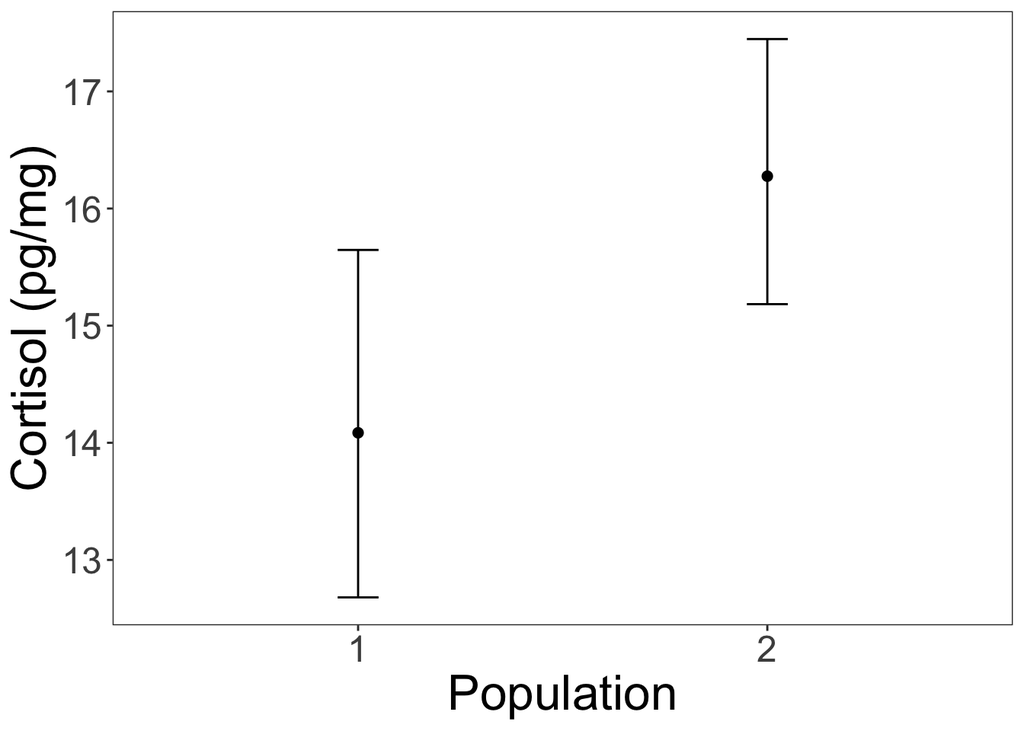

Figure 1: The mean cortisol levels for wolves in populations 1 and 2. Error bars show 95% confidence intervals

## References

R Core Team. (2024). *R: A language and environment for statistical computing*. Vienna, Austria: R Foundation for Statistical Computing. Retrieved from https://www.R-project.org/